# scRNAseq Interstitial cells

Marion Hardy

2024-02-15

# Introduction

Data from our collaborator Panagiotis rds file for a SingleCellExperiment object containing the single cell data for **the interstitial cells** of *Hydra Vulgaris* during multiples stages of regeneration after bisection:

https://www.dropbox.com/scl/fi/dg76sigjnj5u6qr06xk79/sce_interstitial_Juliano.rds?rlkey=f0y3lqt0wdcwq652zisnrpf9t&dl=0

BUT they mapped it to *Hydra Magnipapillata (105)* “Drop-seq reads from 15 libraries generated for Hydra vulgaris strain AEP were mapped to the 2.0 genome assembly of closely related Hydra vulgaris strain 105 (available at https://research.nhgri.nih.gov/hydra/) and processed using the Hydra 2.0 gene models. Strain Hydra vulgaris 105 was formerly referred to as Hydra magnipapillata 105.”

The coldata of the object contain cell annotation including

- quality metrics: nFeature nCount (not MT percentage interestingly)
- batch info: either 2869 (3162 barcodes), 3113 (10352 barcodes), 3271 (13279 barcodes), 3357 (3875 barcodes)
- originating experiments (head or foot regeneration)
- experimental time points
- pseudo-axis assignment (vals.axis ranging from 0-1, increasing in the foot-tentacle direction)
- mitotic and apoptotic signatures indices from 0 to 1

The rowdata contains gene annotation, using Entrez-gene identifiers. I have also noticed that in the sce objects there’s

- PCA, tSNE and UMAP coordinates for reduced dimensions + corrected for batch values
- assay metafeatures hold gene_id, product, gene, is.rib.prot.gene (T/F), HypoMarkers (T/F), ccyle (T/F), apopt (T/F) etc

I converted the sce objects 6.6gb into a seurat object 2.2 gb and checked that all cited parameters could be found in it.

# Data loading

```r
head(seurat@meta.data)
```

```
##                             orig.ident nCount_originalexp nFeature_originalexp
## ACAGGGATCTCTGCTG__3271F1 SeuratProject           83087.62                 6814
## GAACTGTCAACAGCTT__3271F1 SeuratProject           75972.80                 6640
## TGTTGAGCATCCCACT__3271F1 SeuratProject           84055.77                 6743
## TCACACCGTTGCAACT__3271F1 SeuratProject           79379.06                 7144
## TTTGATCCAACTCGAT__3271F1 SeuratProject           80891.62                 6978
## CGCATAAAGTTCACTG__3271F1 SeuratProject           79068.07                 6626
##                          experiment      sum detected    total retain batch
## ACAGGGATCTCTGCTG__3271F1     3271F1 83087.62     6814 83087.62   TRUE  3271
## GAACTGTCAACAGCTT__3271F1     3271F1 75972.80     6640 75972.80   TRUE  3271
## TGTTGAGCATCCCACT__3271F1     3271F1 84055.77     6743 84055.77   TRUE  3271
## TCACACCGTTGCAACT__3271F1     3271F1 79379.06     7144 79379.06   TRUE  3271
## TTTGATCCAACTCGAT__3271F1     3271F1 80891.62     6978 80891.62   TRUE  3271
## CGCATAAAGTTCACTG__3271F1     3271F1 79068.07     6626 79068.07   TRUE  3271
##                          class     EXP_TIME      EXP vals.axis_k25 vals.ccycle
## ACAGGGATCTCTGCTG__3271F1     1 REG_FOOT_t96 REG_FOOT     0.3364188   0.1608466
## GAACTGTCAACAGCTT__3271F1     1 REG_FOOT_t96 REG_FOOT     0.3576079   0.1400965
## TGTTGAGCATCCCACT__3271F1     1 REG_FOOT_t96 REG_FOOT     0.3540071   0.1364451
## TCACACCGTTGCAACT__3271F1     1 REG_FOOT_t96 REG_FOOT     0.4035267   0.1372711
## TTTGATCCAACTCGAT__3271F1     1 REG_FOOT_t96 REG_FOOT     0.3317294   0.1659392
## CGCATAAAGTTCACTG__3271F1     1 REG_FOOT_t96 REG_FOOT     0.3365693   0.1491224
##                          vals.apopt
## ACAGGGATCTCTGCTG__3271F1 0.05622343
## GAACTGTCAACAGCTT__3271F1 0.06828800
## TGTTGAGCATCCCACT__3271F1 0.07038218
## TCACACCGTTGCAACT__3271F1 0.06735781
## TTTGATCCAACTCGAT__3271F1 0.05826005
## CGCATAAAGTTCACTG__3271F1 0.06114139
```

```r
table(seurat@meta.data$batch, seurat@meta.data$EXP_TIME)
```

```
##
##        REG_FOOT_t0 REG_FOOT_t12 REG_FOOT_t24 REG_FOOT_t48 REG_FOOT_t6
##   2869           0            0            0            0           0
##   3113           0            0            0            0           0
##   3271        3054         2623         2483            0        2929
##   3357           0            0            0         1818           0
##
##        REG_FOOT_t96 REG_HEAD_t0 REG_HEAD_t12 REG_HEAD_t24 REG_HEAD_t48
##   2869            0           0            0            0            0
##   3113            0        3486         2173         1580            0
##   3271         2190           0            0            0            0
##   3357            0           0            0            0         2057
##
##        REG_HEAD_t6 REG_HEAD_t96
##   2869           0         3162
##   3113        3113            0
##   3271           0            0
##   3357           0            0
```

```r
head(Features(seurat))
```

```
## [1] "101235239" "100216373" "105843097" "101235416" "100198891" "100202457"
```

# QC

## No filtering applied

The gene names looking like LOC1248…. are actually all symbols of unnamed regions If you go through the list of genes seen, none of them are mitochondrial but they do have descriptions

- This data probably should be aligned on the matching genome
- Why are there no mitochondrial genes in the Hydra_05_v3 construct?

Annotations can be found here: https://www.ncbi.nlm.nih.gov/datasets/gene/GCF_022113875.1/

This means that I cannot regress out the variability that comes from the presence of mitochondrial genes since it seems like there aren’t any. I can still regress out a possible batch effect though.

```r
head(seurat@assays[["originalexp"]]@meta.features) # none of the genes start with "mt"
```

```
##             gene_id                                   product         gene
## 101235239 101235239     uncharacterized protein PFB0145c-like LOC101235239
## 100216373 100216373                                  tRNA-Ile    trnai-aau
## 105843097 105843097       zinc finger MYM-type protein 5-like LOC105843097
## 101235416 101235416              uncharacterized LOC101235416 LOC101235416
## 100198891 100198891 b(0,+)-type amino acid transporter 1-like LOC100198891
## 100202457 100202457                    nucleoporin Nup43-like LOC100202457
##           chromosome_name is.expressed is.rib.prot.gene body_axis.markers
## 101235239  NW_004166867.1         TRUE            FALSE             FALSE
## 100216373  NW_004166867.1        FALSE            FALSE             FALSE
## 105843097  NW_004166867.1        FALSE            FALSE             FALSE
## 101235416  NW_004166867.1        FALSE            FALSE             FALSE
## 100198891  NW_004166867.1         TRUE            FALSE             FALSE
## 100202457  NW_004166867.1         TRUE            FALSE             FALSE
##           ec.Markers i.Markers en.Markers all.markers extremities.markers
## 101235239      FALSE     FALSE      FALSE       FALSE               FALSE
## 100216373      FALSE     FALSE      FALSE       FALSE               FALSE
## 105843097      FALSE     FALSE      FALSE       FALSE               FALSE
## 101235416      FALSE     FALSE      FALSE       FALSE               FALSE
## 100198891      FALSE     FALSE      FALSE       FALSE               FALSE
## 100202457      FALSE     FALSE      FALSE       FALSE               FALSE
##           TentMarkers HypoMarkers BodVarGenes ccycle apopt
## 101235239       FALSE       FALSE       FALSE  FALSE FALSE
## 100216373       FALSE       FALSE       FALSE  FALSE FALSE
## 105843097       FALSE       FALSE       FALSE  FALSE FALSE
## 101235416       FALSE       FALSE       FALSE  FALSE FALSE
## 100198891       FALSE       FALSE       FALSE  FALSE FALSE
## 100202457       FALSE       FALSE       FALSE  FALSE FALSE
```

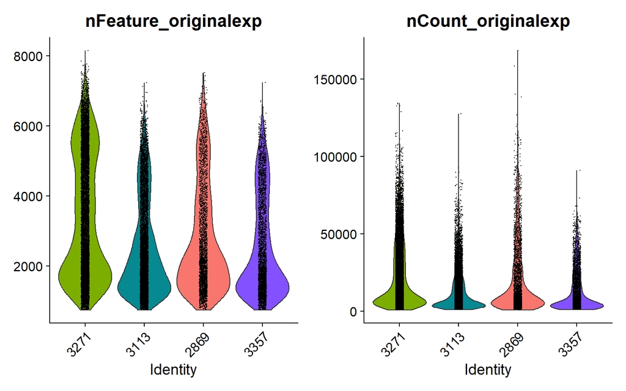

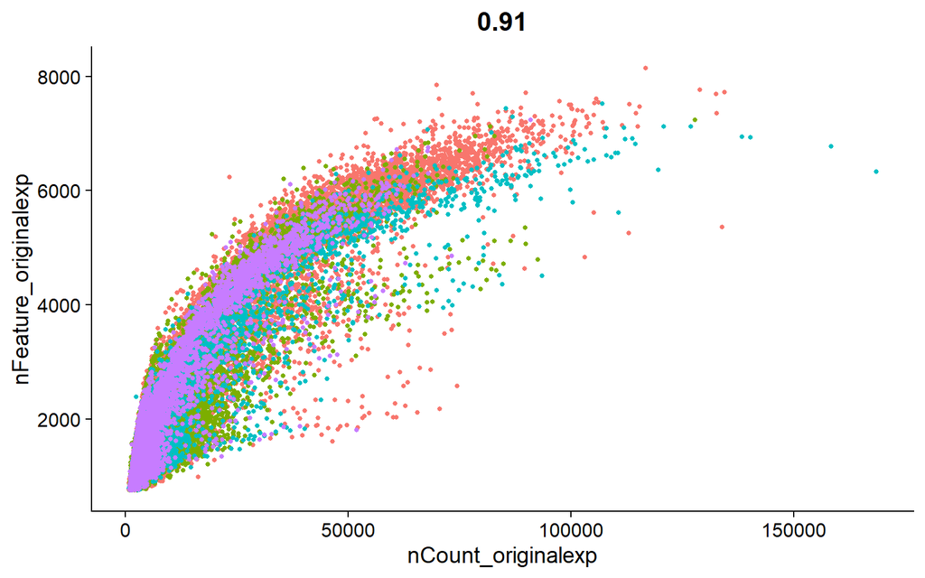

0.91 for correlation between nFeature and nCount is a good score. As a reminder, nFeature is number of unique RNAs (gene that matched at least one UMI) found in a droplet and nCount is number of total molecules found in a droplet. Ideally they’d be exactly proportional?

## Filtering applied

Here, we filter away cells that have unique feature counts(genes) over 6000 or less than 200. Too many features could indicate a doublet too little might indicate an empty droplet

We should also filter away cells that have > 10% mitochondrial counts

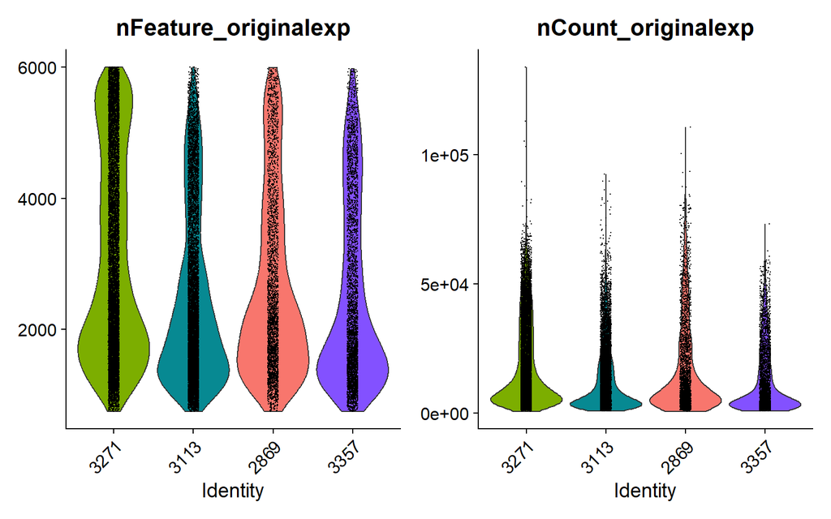

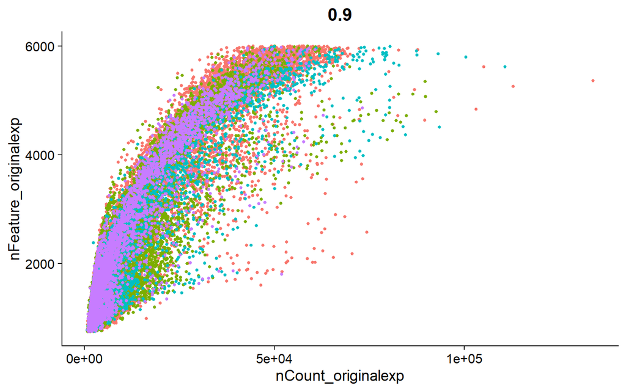

# Normalization/scaling

SCTransform is better than using the standard (old) normalization pipeline because it does negative binomial regression (just as DESeq2 does for RNAseq) which does variance regression that normalization did not do>

“…omits the need for heuristic steps including pseudocount addition or log-transformation” -satijalab

Interestingly, regressing out the batches lead to more distinct cell populations on the PCA.

[output not shown]

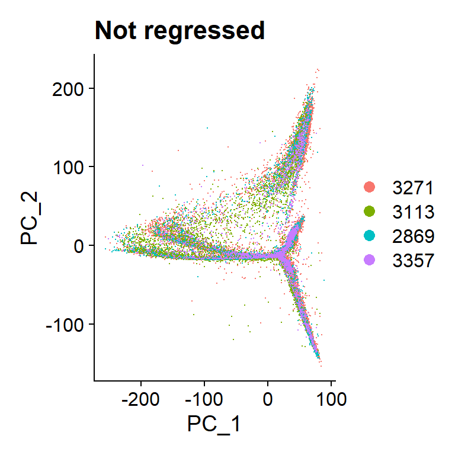

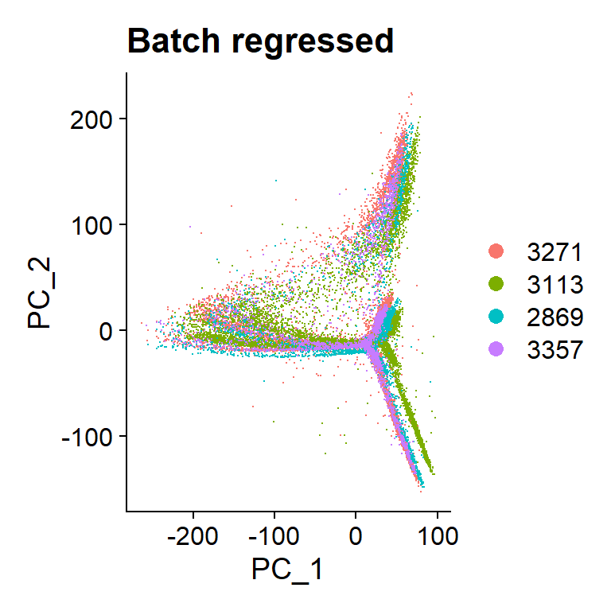

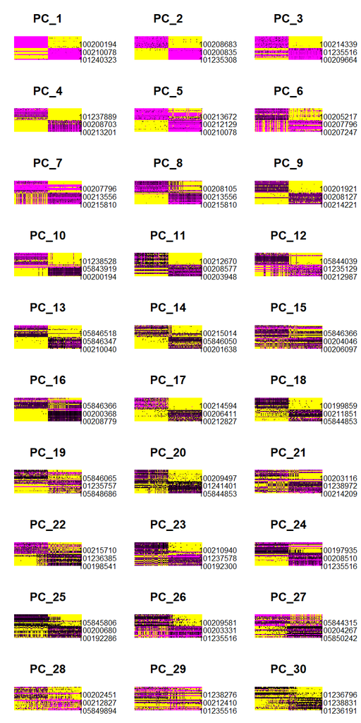

### Not regressed

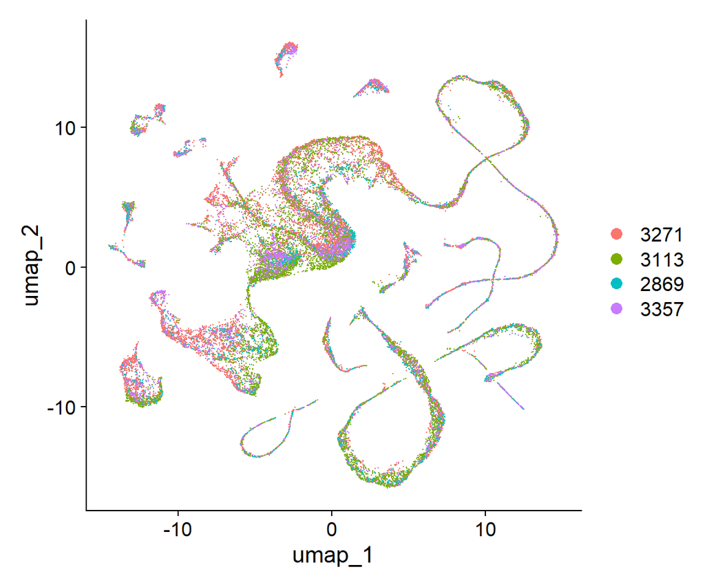

```
## Modularity Optimizer version 1.3.0 by Ludo Waltman and Nees Jan van Eck
##
## Number of nodes: 29280
## Number of edges: 889358
##
## Running Louvain algorithm...
## Maximum modularity in 10 random starts: 0.9915
## Number of communities: 13
## Elapsed time: 2 seconds
```

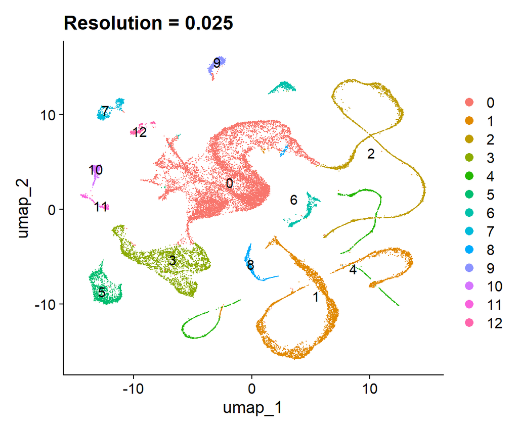

```
## Modularity Optimizer version 1.3.0 by Ludo Waltman and Nees Jan van Eck
##
## Number of nodes: 29280
## Number of edges: 889358
##
## Running Louvain algorithm...
## Maximum modularity in 10 random starts: 0.9832
## Number of communities: 21
## Elapsed time: 2 seconds
```

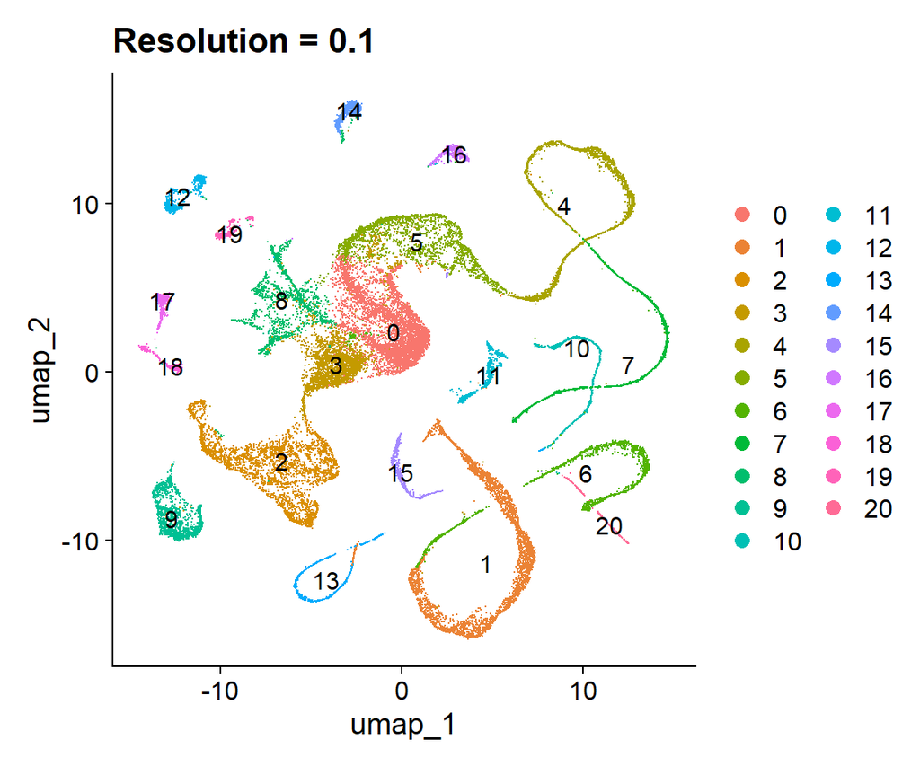

```
## Modularity Optimizer version 1.3.0 by Ludo Waltman and Nees Jan van Eck
##
## Number of nodes: 29280
## Number of edges: 889358
##
## Running Louvain algorithm...
## Maximum modularity in 10 random starts: 0.9705
## Number of communities: 25
## Elapsed time: 2 seconds
```

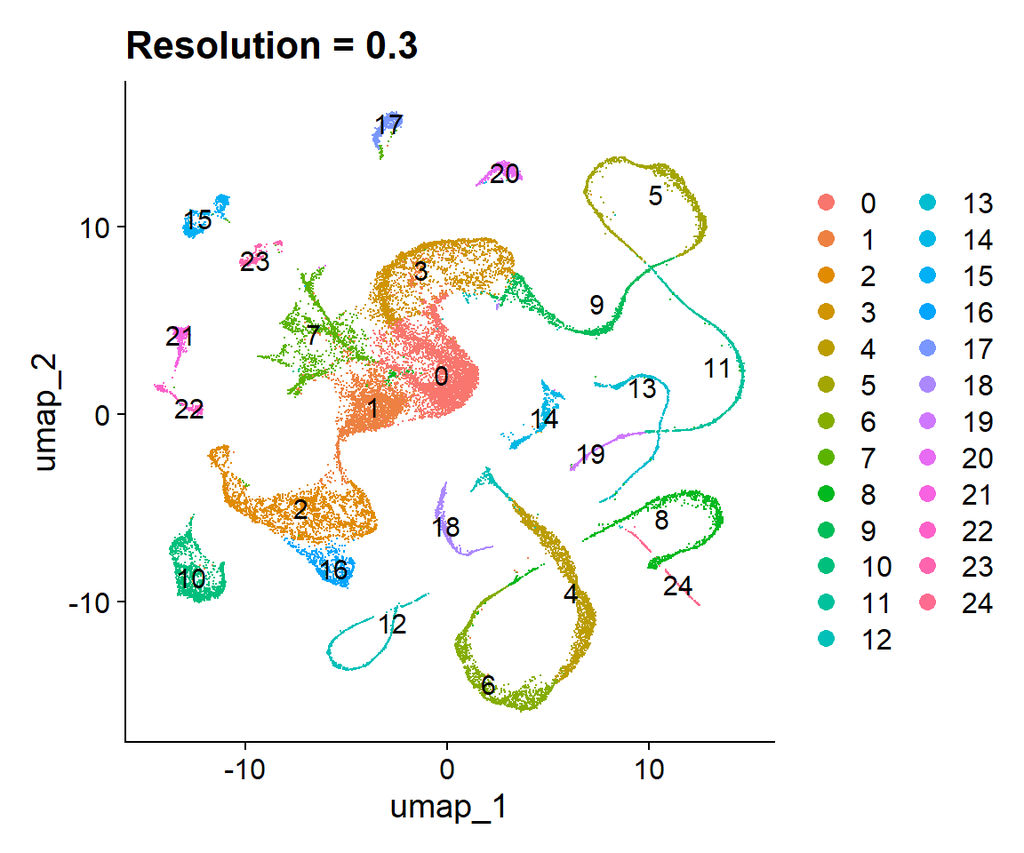

### Batch regressed

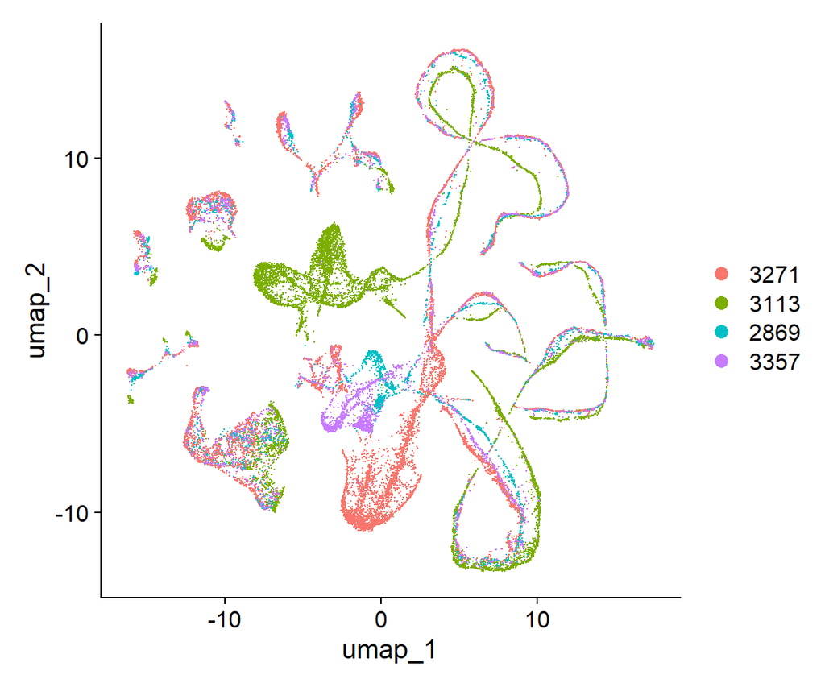

```
## Modularity Optimizer version 1.3.0 by Ludo Waltman and Nees Jan van Eck
##
## Number of nodes: 29280
## Number of edges: 869120
##
## Running Louvain algorithm...
## Maximum modularity in 10 random starts: 0.9923
## Number of communities: 13
## Elapsed time: 2 seconds
```

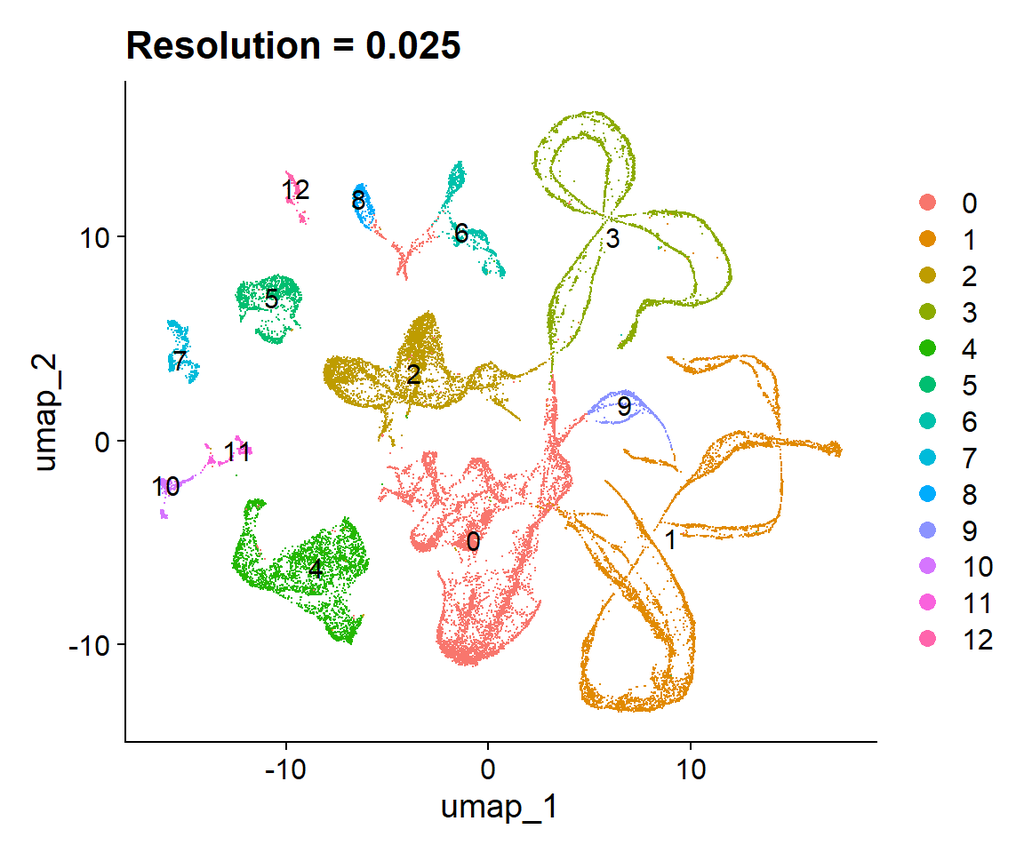

```
## Modularity Optimizer version 1.3.0 by Ludo Waltman and Nees Jan van Eck
##
## Number of nodes: 29280
## Number of edges: 869120
##
## Running Louvain algorithm...
## Maximum modularity in 10 random starts: 0.9848
## Number of communities: 22
## Elapsed time: 2 seconds
```

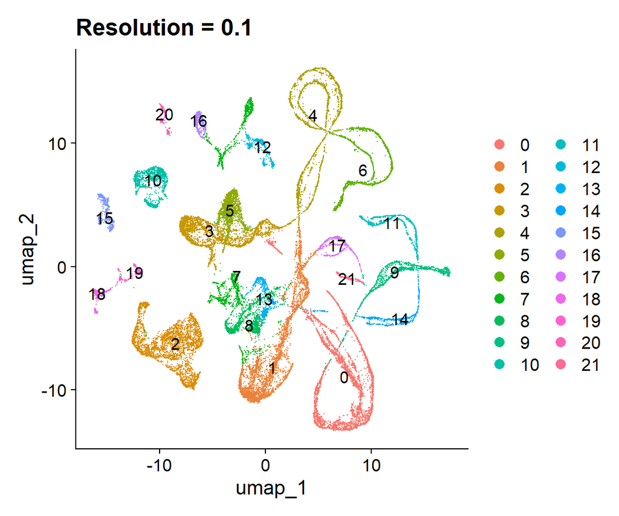

```
## Modularity Optimizer version 1.3.0 by Ludo Waltman and Nees Jan van Eck
##
## Number of nodes: 29280
## Number of edges: 869120
##
## Running Louvain algorithm...
## Maximum modularity in 10 random starts: 0.9747
## Number of communities: 31
## Elapsed time: 1 seconds
```

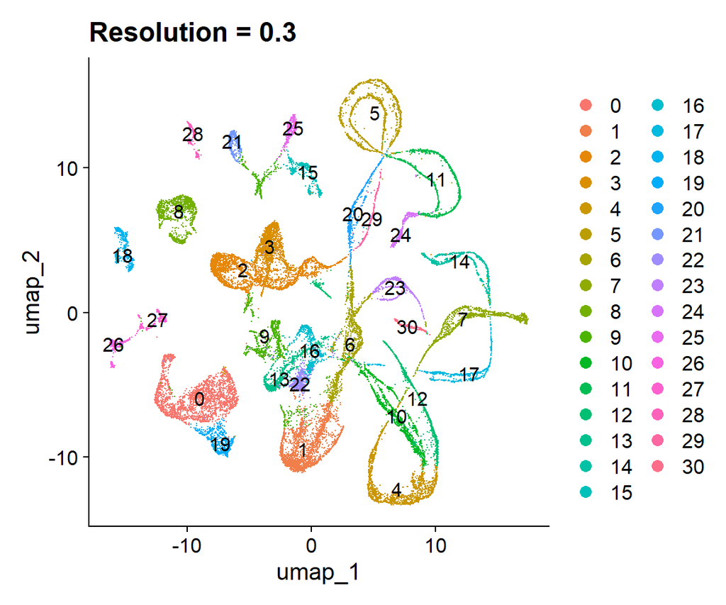